# RDD Fuzzy

ECON 474 Econometrics of Policy Evaluation

# 1 Preliminary Setup

To get us started, let’s load in `tidyverse`, `fixest`, and the data.

```r
library(haven)
library(tidyverse)
library(fixest)

df = read_csv("C:/Users/johnj/Dropbox/Julian/Academia/UIUC/Semester 12 Spring 2023/ECON474sp23/Data/RDD3 Angrist and Lavy grade5.csv")
```

# 2 School Enrollment and Class Sizes

Before we get to running regressions, we are going to visually determine if the Maimonides rule actually has any bite. We will do so by plotting average classroom size for every each cohort enrollment size. But before we can make the plot, it will be useful to define the Maimonides rule as a `function` to create the plot and for creating the instrument later on.

```r
maimonides_rule <- function(x) {x / (floor((x - 1)/40) + 1)}
```

Because we are plotting the average classroom size for each cohort size instead of estimating a regression, we need to create a new `data.frame` that is an aggregation of the regression data.

```r
df_plot = df %>%
  group_by(enrollment) %>%
  summarise(avg_class_size = mean(classize))
```

## 2.1 Figure Ia

We are hoping that the observed average class size versus cohort enrollment size does actually follow the predicted class size if schools are following the Maimonides rule. To verify this, we are going to replicate Figure Ia, somewhat like a visual first stage.

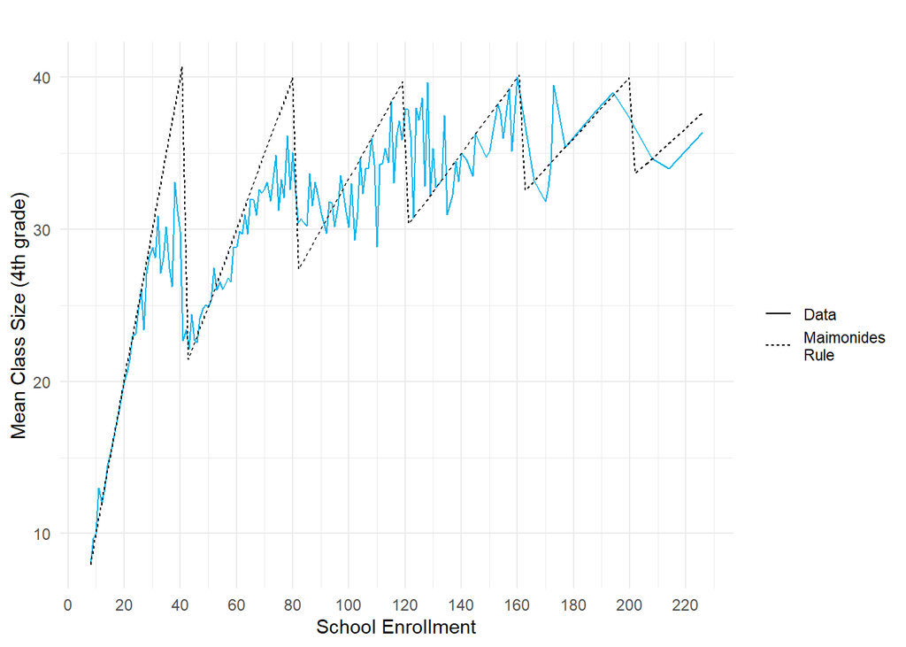

```r
ggplot(df_plot, aes(x = enrollment, y = avg_class_size)) +
  geom_line(aes(linetype = "Data"), col = 'deepskyblue2') +
  stat_function(aes(linetype = "Maimonides\nRule"),
                fun = maimonides_rule) +
  scale_x_continuous(breaks = seq(0, 220, by = 20)) +
  theme_minimal() +
  labs(x = "School Enrollment",
       y = "Mean Class Size (4th grade)",
       title = "",
       linetype = "")
```

# 3 Lab: Fuzzy RDD and You

Now it’s your turn! Add a new variable `iv_maimonides` to the regression data frame (`df`) by plugging the variable `enrollment` into the `mainmonides_rule()` function.

## 3.1 Biased OLS

We are next going to run **three regressions in one line**. Using `feols()`, run a regression of `avgmath` on `classize`, `pct_disadv`, and `enrollment` by plugging the $X$ variables into the `csw()` function (cumulative stepwise) separated by a comma. Cluster the standard erros by `schlcode`. Save the regression as an object named `fit_ols`

## 3.2 Reduced Form

Do exactly the same steps as the previous subsection, except for estimate the reduced form. Save the reduced from as an object named `fit_iv_rf`

## 3.3 Fuzzy RDD

Time to estimate your first fuzzy RDD! Still using `avgmath` as the $Y$ variable, this time plug `pct_disadv` and `enrollment` into `csw0()`. Specify the endogenous variable and instrument appropriately.

## 3.4 Comparing Results

Produce an etable over your nine regression (three objects) with standard errors set below; show the number of observations, $R^2$, and F-statistic; and `order` the variables such that `Intercept`, `classize` and `iv_maimonides` comes first.

1. Compare across the specifications as controls are added. Do you think that the percent of students disadvataged and cohorot enrollment size are omitted varaibles? Why or why not?

**Answer**:

2. Figure Ia suggested that we have a strong first stage. Does the estimated first stage agree?

**Answer**:

3. Compare the naïve regression in column 1 to the fully specified fuzzy RDD in column 9. What are the policy implications from the coefficient estimates on classroom size from the two columns?

**Answer**: